# Lab 08 - Bootstrapping

Nonparametric statistics ay 2022/2023

2022/10/20

*Disclaimer: The present material has been slightly adapted from the original R script prepared by me for the a.y. 2020/2021 Nonparametric statistics course. I hereby assume responsibility for any error that may be present in this document, I do apologise for them and invite you to let me know.*

```r
seed=2781991
B=10000
library(progress)
```

Let’s start by loading and displaying some data, regarding the growth of some orange trees (specifically, the diameter of their trunk)

```r
data("Orange")
Orange
```

|  | Tree | age | circumference |
| --- | --- | --- | --- |
| 1 | 1 | 118 | 30 |
| 2 | 1 | 484 | 58 |
| 3 | 1 | 664 | 87 |
| 4 | 1 | 1004 | 115 |
| 5 | 1 | 1231 | 120 |
| 6 | 1 | 1372 | 142 |
| 7 | 1 | 1582 | 145 |
| 8 | 2 | 118 | 33 |
| 9 | 2 | 484 | 69 |
| 10 | 2 | 664 | 111 |

[output cut: 25 more lines]

You see that we have a longitudinal dataset, with repeated measurements for 5 different trees. Let’s select just one of them

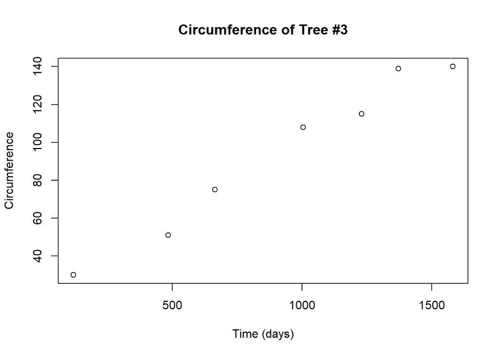

```r
O_3=subset(Orange,Orange$Tree==3)
attach(O_3)
#let's have a look at the data
plot(age,circumference,main='Circumference of Tree #3',xlab = 'Time (days)',ylab = 'Circumference')
```

The temporal evolution of the circumference seems to be relatively well described by a logistic curve… How can I estimate it?

```r
logistic=function(t,L,k,midpoint){L/(1+exp((midpoint-t)/k))}
```

Here $t$ is the independent variable, $L$ is the asymptote parameter, $k$ is the growth rate and $midpoint$ is the point in time when the derivative of the curve is at its maximum level (the peak, if you want an epidemic analogy). How do I estimate the parameters $L, k,midpoint$ in such nonlinear relationship? I use nls

```r
model=nls(circumference ~ logistic(age,L,k,midpoint) ,
          start=list(L=150, k=500, midpoint=700))

summary(model)
```

```
##
## Formula: circumference ~ logistic(age, L, k, midpoint)
##
## Parameters:
##          Estimate Std. Error t value Pr(>|t|)
## L          158.83      15.09  10.529  0.00046 ***
## k          400.95      74.33   5.394  0.00571 **
## midpoint   734.84     102.59   7.163  0.00201 **
## ---
## Signif. codes:  0 '***' 0.001 '**' 0.01 '*' 0.05 '.' 0.1 ' ' 1
##
## Residual standard error: 6.258 on 4 degrees of freedom
##
## Number of iterations to convergence: 4
## Achieved convergence tolerance: 6.516e-06
```

Let’s plot the estimated curve now: I need to start by generating my predictions on a fine grid

```r
age_fine=seq(0,2500)
circumference_fine=predict(model,list(age=age_fine))
```

Then I plot my original points, and I overlay to them the predicted curve

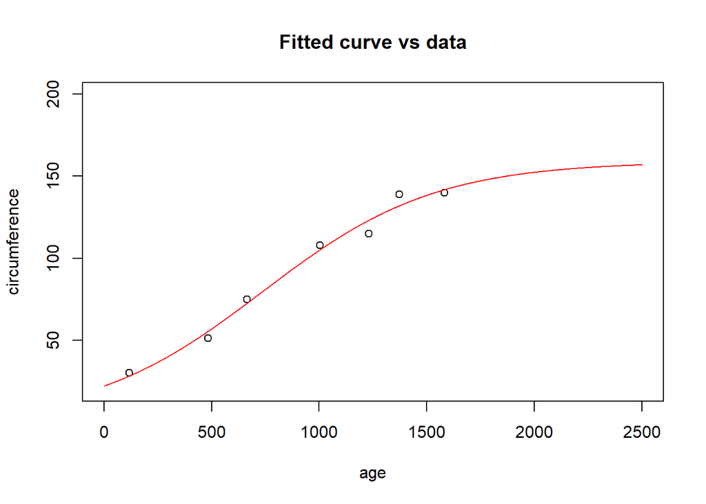

```r
plot(age,circumference,main='Fitted curve vs data',xlim=c(0,2500),ylim=c(20,200))
lines(age_fine,circumference_fine,col='red')
```

What if I want to make inference about these parameters? Either I impose a parametric model on the error term, or, as you expect, I can use the boostrap.

Let’s start then by computing the residuals:

```r
fitted.obs=predict(model)
res.obs=circumference-fitted.obs
```

And, let’s start by computing confidence intervals for the asymptote parameter

```r
L.obs = summary(model)$parameters[1,1]
T.boot.L = numeric(B)
formula.b = response.b ~ logistic(age,L,k,midpoint)

pb <- progress_bar$new(
  format = "  processing [:bar] :percent eta: :eta",
  total = B, clear = FALSE)

set.seed(seed)

for(b in 1:B) {


  response.b <- fitted.obs + sample(res.obs, replace = T)
  fm.b <- nls(formula.b ,start=list(L=150, k=500, midpoint=700))

  sm.b = summary(fm.b)

  T.boot.L[b] = sm.b$parameters[1,1]


  pb$tick()

}
```

let’s now compare the bootstrap distribution of the parameter with the parameter itself…

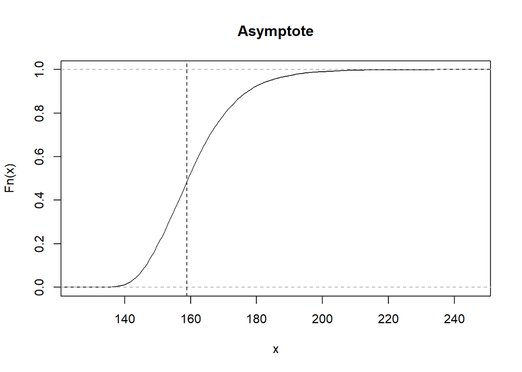

```r
plot(ecdf(T.boot.L), main='Asymptote')
abline(v=L.obs, lty=2)
```

Using the boostrap distribution of the parameter, I can compute without the need of distributional assumptions and/or approximations the standard deviation of the estimate of this parameter.

```r
sd(T.boot.L)
```

```
## [1] 12.62659
```

As well as its bias

```r
mean(T.boot.L)-L.obs
```

```
## [1] 2.08683
```

```r
MSE=var(T.boot.L) + (mean(T.boot.L)-L.obs)^2
```

What if I want to compute a confidence interval around the parameter? I can use the classical reverse-percentile approach:

```r
alpha <- 0.05
right.quantile.L <- quantile(T.boot.L, 1 - alpha/2)
left.quantile.L  <- quantile(T.boot.L, alpha/2)

CI.RP.L <- c(L.obs - (right.quantile.L - L.obs),L.obs ,L.obs - (left.quantile.L - L.obs))
names(CI.RP.L)=c('lwr','lvl','upr')
CI.RP.L
```

```
##      lwr      lvl      upr
## 126.7201 158.8293 175.9191
```

And, let’s visualise them

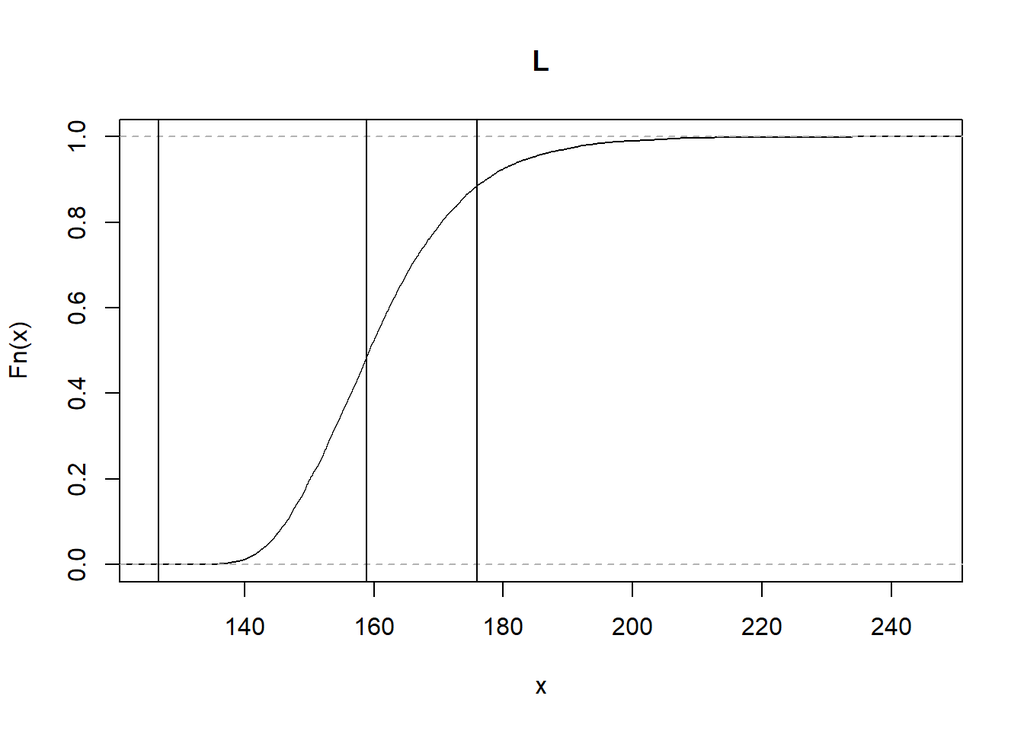

```r
plot(ecdf(T.boot.L), main='L')
abline(v = L.obs, lty=2)
abline(v = CI.RP.L)
```

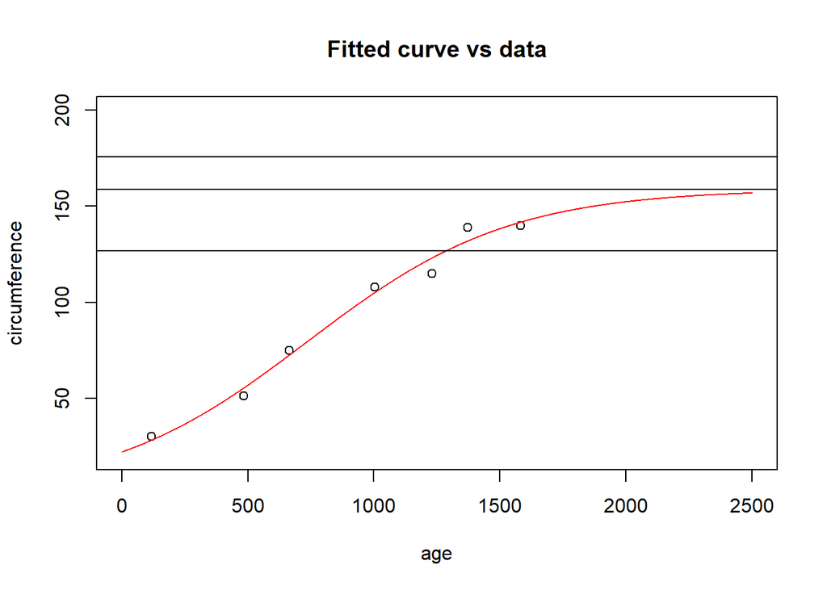

```r
plot(age,circumference,main='Fitted curve vs data',xlim=c(0,2500),ylim=c(20,200))
lines(age_fine,circumference_fine,col='red')
abline(h=L.obs, lty=2)
abline(h = CI.RP.L)
```